# Understanding Participation Patterns: Classifying MA-User Behavior

```python
from typing import List, Optional

import matplotlib.pyplot as plt
import pandas as pd
import seaborn as sns
from matplotlib import ticker
from sklearn.cluster import HDBSCAN
from sklearn.metrics import silhouette_score
from scipy.spatial import distance
from sklearn.preprocessing import Normalizer, StandardScaler
from umap import UMAP

from src import utils
from src.query_engine import QueryEngine

# Get configuration parameters and logger for the current session
config = utils.get_config()

# Initialize query engine
qe = QueryEngine()

# %load_ext autoreload
# %autoreload 2

PALETTE = "Spectral"


def umap_embeddings_viewer(
    df: pd.DataFrame,
    labels: pd.Series,
    n_components: int = 2,
    n_neighbors: int | List[int] = [15],
    supervised: bool = False,
) -> pd.DataFrame:
    """Perform feature dimensional reduction with UMAP and display the results"""

    def umap_model(n_components: int = 2, n_neighbors: int = 15):
        """Instantiate UMAP with default parameters"""
        return UMAP(
            n_neighbors=n_neighbors,
            n_components=n_components,
            metric="cosine",
            densmap=True,
        )

    if isinstance(n_neighbors, int):
        n_neighbors = [n_neighbors]

    dims = [f"Dim{i}" for i in range(1, n_components + 1)]
    X = df.to_numpy()
    dimred = []
    for n in n_neighbors:
        if supervised:
            model = umap_model(n_components, n).fit(X, y=labels.factorize()[0])
        else:
            model = umap_model(n_components, n).fit(X)
        df_dimred = pd.DataFrame(model.embedding_, columns=dims, index=df.index)
        df_dimred["label"] = labels
        df_dimred["neighbors"] = n

        dimred.append(df_dimred)

    df_dimred = pd.concat(dimred, axis=0)

    if n_components == 2:
        if len(n_neighbors) > 1:
            sns.relplot(
                data=df_dimred,
                x="Dim1",
                y="Dim2",
                col="neighbors",
                col_wrap=2,
                hue="label",
                hue_order=sorted(labels.unique()),
                kind="scatter",
                palette=PALETTE,
                facet_kws={"sharex": False, "sharey": False},
            )
        else:
            sns.scatterplot(
                data=df_dimred,
                x="Dim1",
                y="Dim2",
                hue="label",
                hue_order=sorted(labels.unique()),
                palette=PALETTE,
            )
    elif n_components == 3:
        for n in n_neighbors:
            p = sns.pairplot(
                df_dimred.query(f"neighbors == {n}").drop("neighbors", axis=1),
                hue="label",
                hue_order=sorted(labels.unique()),
                palette=PALETTE,
                aspect=2,
            )
            p.fig.suptitle(f"Number of Neighbors: {n}", y=1.08)
    else:
        raise ValueError(
            "Only 2 or 3 number of components (dimension) can be displayed."
        )
    plt.show()
    return df_dimred


def user_labels(df: pd.DataFrame, std_lim: int = 1000):
    """Hierarchical classification based on geo-location heuristic rules"""

    if df["n_clusters"] == 0:
        if df["std_utm"] >= std_lim:
            return "sparse narrow"
        else:
            return "sparse wide"
    elif df["n_clusters"] == 1:
        if df["std_utm"] >= std_lim:
            return "aggregated wide"
        else:
            return "aggregated narrow"
    elif df["n_clusters"] > 1:
        return "multi-aggregation"
    else:
        return "sporadic"


def viz_users_stats(df: pd.DataFrame, ticker_moltip: Optional[int] = None):
    """Display report counts given the classification labels"""

    fig, ax = plt.subplots(2, 1, figsize=(12, 5), sharex=True)
    df_perc = (df.div(df.sum(axis=1), axis=0) * 100).fillna(0)

    df.index = df.index.astype(str)
    df_perc.index = df_perc.index.astype(str)
    df.plot(kind="bar", cmap=PALETTE, width=1, stacked=True, ax=ax[0])
    df_perc.plot(
        kind="bar", rot=30, cmap=PALETTE, width=1, stacked=True, ax=ax[1], legend=False
    )

    if ticker_moltip is not None:
        ax[1].xaxis.set_major_locator(ticker.MultipleLocator(ticker_moltip))
```

Apply the geo-location heuristic clustering of users.

```python
users_stats = pd.read_parquet(config["paths"]["user_ppa_adult"])
users_stats["user_rule_labels"] = users_stats.apply(user_labels, axis=1)
```

Show the percentage distribution of users relative to heuristic labels

```python
(
    users_stats["user_rule_labels"].value_counts()
    / len(users_stats["user_rule_labels"])
    * 100
).round(1).sort_values()
```

```
user_rule_labels
multi-aggregation     0.4
sparse wide           0.5
aggregated wide       1.5
sparse narrow         1.6
aggregated narrow     2.2
sporadic             93.9
Name: count, dtype: float64
```

Show report inflow coming from users classified with heuristic labelling. We can filter in relation to the provenience of the users by specifying 'entity'.

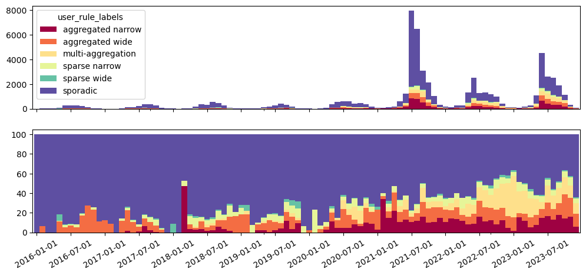

```python
entity = "Total"
# entity = "Netherlands"
users_stats_view = qe.ppa_view_inflow(users_stats, "user_rule_labels", entity=entity)
# viz_users_stats(users_stats_view.drop(["sporadic"], axis=1), ticker_moltip=6)
viz_users_stats(users_stats_view, ticker_moltip=6)
```

Now we apply dimensional reduction and unsupervised clustering to get clusters of users which behavior depends on geo-location and participation quality. We drop the 'sporadic' users from the analysis. Take in account of the following: correlation is present between quality measures, counts present power distributions, n_clusters is discrete while std_utm is continuous

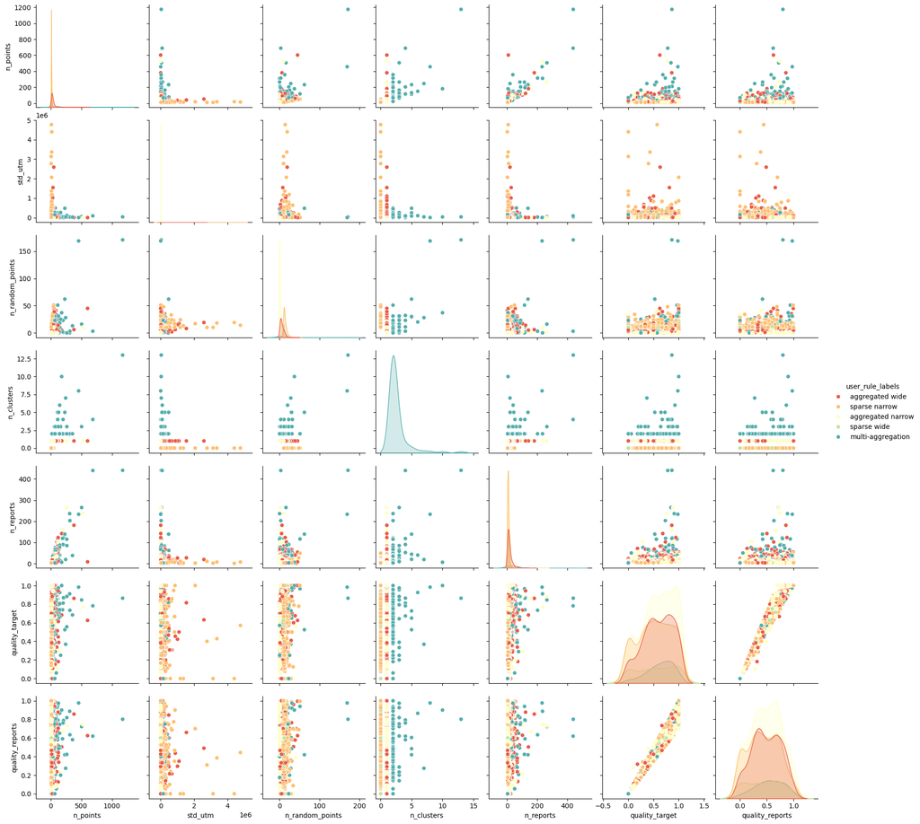

```python
cols = [
    "n_points",
    "std_utm",
    "n_random_points",
    "n_clusters",
    "n_reports",
    "quality_target",
    "quality_reports",
]

users_stats_filt = users_stats.query("user_rule_labels != 'sporadic'")
sns.pairplot(
    users_stats_filt[cols + ["user_rule_labels"]],
    hue="user_rule_labels",
    palette=PALETTE,
)
```

Explore how feature scaling and UMAP parameters influence the dimensional reduction. As a check, we plot the reduced features labelled by the heuristic classification.

```
Raw feature transformation
```

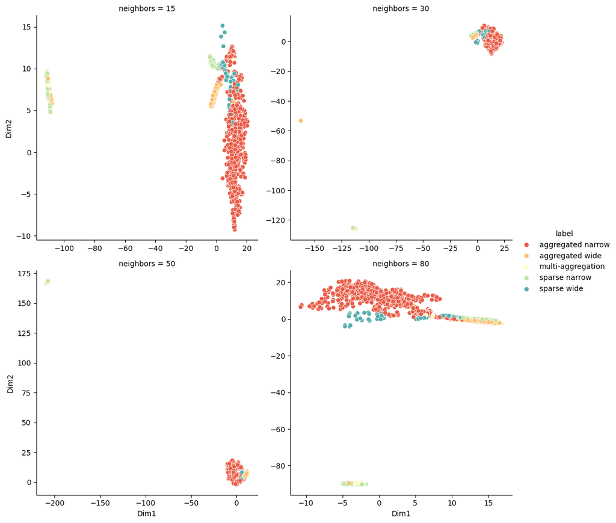

```
Scaler feature transformation
```

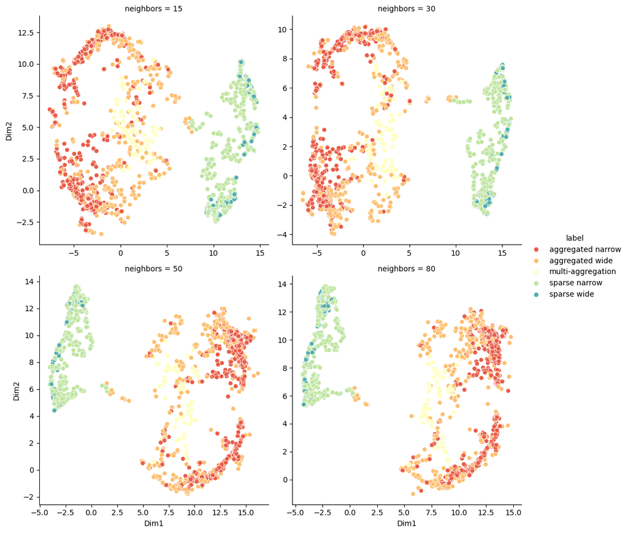

```
Normalizer feature transformation
```

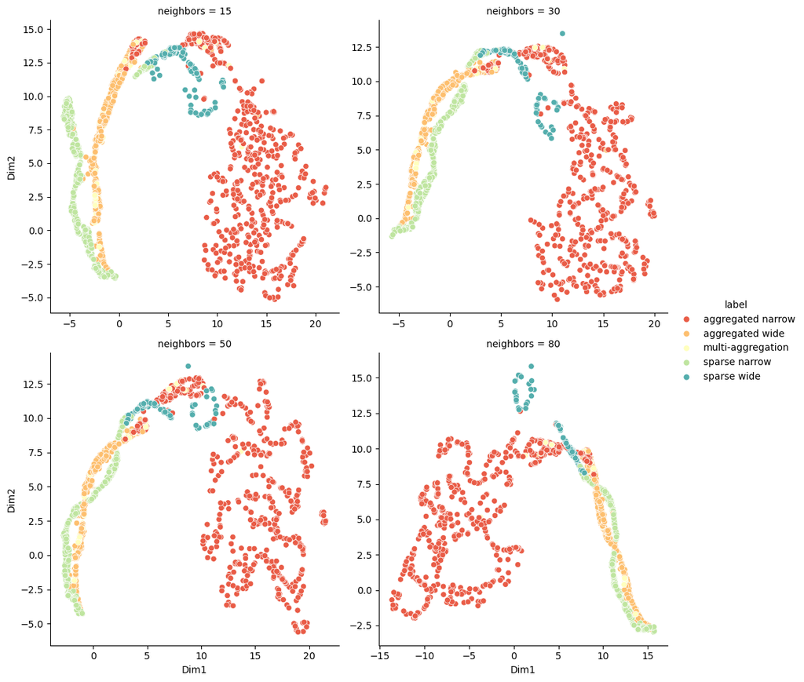

```python
feature_transformers = {
    "raw": None,
    "scaler": StandardScaler(with_std=True),
    "normalizer": Normalizer(norm="max"),
}
n_neighbors = [15, 30, 50, 80]
# n_neighbors = [30]

dimred = {}
for name, ft in feature_transformers.items():
    print(f"{name.capitalize()} feature transformation")
    if ft is not None:
        Xft = ft.fit_transform(users_stats_filt[cols])
    else:
        Xft = users_stats_filt[cols].to_numpy()
    df_ft = pd.DataFrame(Xft, index=users_stats_filt.index)
    Xft_dimred = umap_embeddings_viewer(
        df_ft,
        labels=users_stats_filt["user_rule_labels"],
        n_components=2,
        n_neighbors=n_neighbors,
        supervised=False,
    )
    dimred[name] = (Xft, Xft_dimred)
```

After deciding the optimal hyperparameters, perform clustering with MAP and HDBSCAN. Remember that HDBSCAN assign '-1' label to items that do not belong to any category. Moreover, we use DensMAP with cosine similarity in order to take account of the density distribution and reduce make reduction scale invariant.

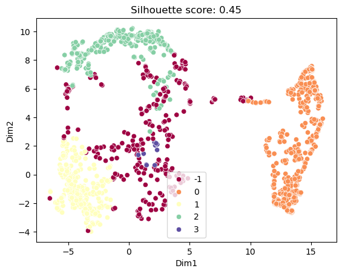

```python
min_samples = 50
n_neighbors = 30
Xft = dimred["scaler"][0]
Xft_dimred = dimred["scaler"][1].query("neighbors == @n_neighbors").iloc[:, :-2]

labels_dimred_cluster = HDBSCAN(
    min_samples=min_samples,
).fit_predict(Xft_dimred)
score = silhouette_score(Xft_dimred, labels_dimred_cluster)
p = sns.scatterplot(
    data=Xft_dimred, x="Dim1", y="Dim2", hue=labels_dimred_cluster, palette=PALETTE
)
p.set_title(f"Silhouette score: {score:.2f}")
```

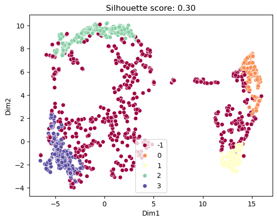

```python
labels_cluster = HDBSCAN(min_samples=min_samples, metric="precomputed").fit_predict(
    distance.squareform(distance.pdist(Xft, metric="cosine"))
)
score = silhouette_score(Xft_dimred, labels_cluster)
sns.scatterplot(
    data=Xft_dimred, x="Dim1", y="Dim2", hue=labels_cluster, palette=PALETTE
)
plt.title(f"Silhouette score: {score:.2f}")
```

At this point we can perform a visual check of distribution separation of classes. We can observe distribution separation even if there is still some overlapping. Note that label -1 is expected to be almost uniform.

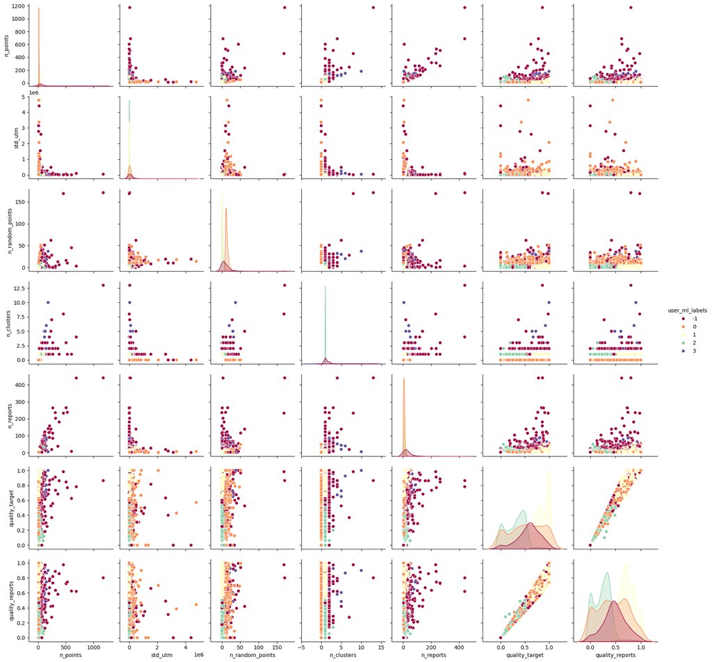

```python
users_stats_filt["user_ml_labels"] = labels_dimred_cluster
sns.pairplot(
    users_stats_filt[cols + ["user_ml_labels"]], hue="user_ml_labels", palette=PALETTE
)
```

Now we can plot the temporal distribution of different of users as they contribute by sending reports. We merge all the reports, by assigning -2 to the 'sporadic' users. However, we can drop 'sporadic' and unlabeled users to focus on the most interesting user types.

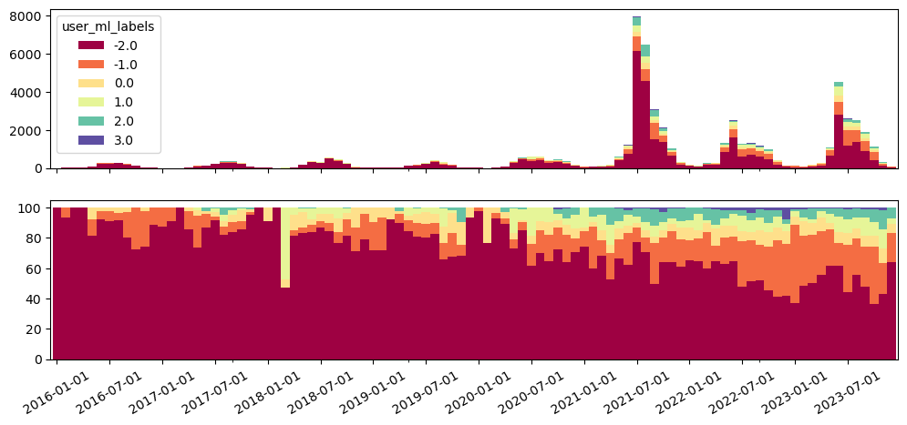

```python
users_stats["user_ml_labels"] = users_stats_filt["user_ml_labels"]
users_stats["user_ml_labels"] = users_stats["user_ml_labels"].fillna(-2)

users_stats_view = qe.ppa_view_inflow(
    users_stats, "user_ml_labels", entity=entity
)
viz_users_stats(users_stats_view, ticker_moltip=6)
# viz_users_stats(users_stats_view.drop([-2, -1], axis=1), ticker_moltip=6)
```